# Overview

## Summary

The data provided in `wnvstormdata` integrates weekly data on tropical cyclone exposure and West Nile Virus confirmed cases for parishes in Louisiana from 2002–2021 to determine if a storm occurred in each parish for the observed week. This data set provides researchers interested in the association between vector-borne disease prevalence and hurricanes with data on cases numbers and when hurricane exposure took place paired by location and time interval.

- parish: A character object of the parish name
- fips: A character object containing the five digit FIPs code for the parish
- startDate: A date object indicating the beginning of the CDC Epidemiological Week
- endDate: A date object indicating the end of the CDC Epidemiological Week
- cases: A numeric object of case numbers occuring within the stated CDC Epidemiological week
- exposure: A numeric object indicating if the parish experienced a storm with winds of at least 34 knots during the epidemiological week
- storm: A character object that states, if a storm exposure occured, which storm it was
- wind: A numeric object containing the maximum sustained wind from a storm, if exposed

```r
data("wnv_2002_2021_stormexposure")
head(wnv_2002_2021_stormexposure)
```

```
#> # A tibble: 6 x 8
#>   parish    fips  startDate  endDate    cases exposure storm  wind
#>   <chr>     <chr> <date>     <date>     <dbl>    <dbl> <chr> <dbl>
#> 1 Jefferson 22051 2004-06-06 2004-06-12     0        0 NA        0
#> 2 Jefferson 22051 2004-06-13 2004-06-19     0        0 NA        0
#> 3 Jefferson 22051 2004-06-20 2004-06-26     0        0 NA        0
#> 4 Jefferson 22051 2004-06-27 2004-07-03     0        0 NA        0
#> 5 Jefferson 22051 2004-07-04 2004-07-10     0        0 NA        0
#> 6 Jefferson 22051 2004-07-11 2004-07-17     0        0 NA        0
```

## Background

West Nile Virus (WNV) is a vector-borne disease of significant concern in public health. Originating in avian life, this virus can be contracted by mosquitoes who become a carrier when they feed off an infected bird and spread it to their next victims. People can become infected when bitten by a mosquito carrying the virus. Individuals who contract it can experience a wide range of symptoms. While most people have an asymptomatic reaction and exhibit no symptoms, some may experience fever, body aches, etc. In severe cases, patients may die from encephalitis or meningitis (“Symptoms, Diagnosis, &Amp; Treatment” 2022).

Several factors influence WNV transmission. These include human behavior, mosquito behavior, and climate factors. Hurricanes have the potential to impact all of these factors. For example, heavy winds may kill mosquito populations during a storm event. However, flooding can create large areas of standing water, which is the ideal breeding climate for mosquito pools. This can lead to West Nile Virus quickly spreading within mosquito pools, increasing the risk of exposure for humans. In addition, if this flooding takes place in residential areas, humans and mosquitoes may be brought into closer and more frequent proximity of one another. This could also increase human risk of exposure to WNV. For example, in the aftermath of Hurricane Katrina, many families were left stranded on their roofs for multiple days awaiting rescue. While waiting, they had to endure several mosquito bites (Caillouët 2020). In order to study any relationship between WNV prevalence and hurricanes, the data for each respective observation must be linked together.

Environmental epidemiology, such as hurricane studies, can require a lot of format-alignment and cleaning. This is a key issue, and a significant time-consuming step, in analytical research. `wnvstormdata` contains data where this step has already been completed. Specifically, data has been converted from PDF fixed-width spacing to RDA format for computer mutation. While considered a good format for reading and publishing, fixed-width text is often difficult for further analysis. The primary challenge in integrating two separate data sets is differing time and space scales. The time objects in the WNV files, for example, is labelled by CDC epidemiological weeks (“West Nile Virus: LA Dept. Of Health” 2022). These need to be converted to a year/month/day format to align with the tropical cyclone wind observation times. Having the format conversion and time-format differentiation fixed will save researchers a lot of time by providing an open-source package with the data ready to go.

## Methods

This data package sources data from the Louisiana Department of Public Health (LDPH) (“West Nile Virus: LA Dept. Of Health” 2022) and National Oceanic and Atmospheric Administration (NOAA) (2023). The disease data needed from LDPH is found in PDFs, which are not an ideal format for further analysis. There are weekly and annual summary PDFs from 2002–2021. Extracting information from these files manually is time consuming and can introduce errors. With this data set, we have already gone through all of the files and extracted needed data. This work speeds up the process for researchers and reduces the risk of clerical errors.

In addition, the disease and storm data need to be integrated for proper analysis. The disease data and hurricane data are originally collected in different time intervals. The WNV confirmed case data is presented in week numbers out of the year, while the storm data is recorded in year/month/day format, with 15 minute increments for each wind observation in the generated wind fields. The CDC weeks have been converted to intervals notated in the year/month/day format so that both data sets align. This was used to identify if a hurricane occurred during each week of observation. The other aspect of determining storm exposure is location. For this step, the `stormwindmodel` R package was used to model wind fields for storm tracks recorded in the NOAA dataset. The `get_grid_winds` function uses parish coordinates to determine which parish a wind field observation was made in (Anderson et al. 2021). The grid_id provided from the function was then filtered by each WNV observation’s FIPs code. We considered an observance week to be exposed if there were sustained winds of at least 34 knots during the week period and in the parish’s geographic coordinates. 34 knots is the threshold for which NOAA classifies a tropical cyclone as a tropical storm (“Tropical Cyclone Climatology” 2021). Wind speeds of at least 34 knots are considered gale force, meaning they are strong and persistent. These are described on the Beaufort Wind Scale as the wind strength at which twigs and small branches start falling off of trees(US Department of Commerce 2016). For these exposed observations, the name of the storm the winds were from is also noted in the storm column.

## Examples of Working with Data

With links between WNV prevalence and hurricane storms per year, overall case counts can be compared with storm paths. An example of this is displayed with Hurricane Katrina, seen in Figure 1.

The first step in modeling confirmed case counts with a storm is creating our storm path. First, we use `hurr_tracks` from `hurricaneexposuredata` and filter out the wind observations for hurricane Katrina:

```r
#Storm track
storm <- hurr_tracks %>%
    mutate(ymd_date = lubridate::ymd_hm(date)) %>%
  tidyr::separate(storm_id, c("storm", "year")) %>%
  filter(storm == "Katrina")

storm2 <- storm %>%
  filter(28 <latitude & latitude<35)
```

For our sample model, we are interested in cases in Louisiana accuring in different intervals after the storm. First, we create intervals for each of the periods of interest: the week of the storm, one month after the storm, then the rest of the year after Katrina hit. The `wnv_2002_2021_stormexposure` dataset is filtered for each of these intervals, initially made into different dataframes. Then, for each respective interval, the cases are grouped by parish and summarized into the total cases. These interval data frames are all joined together. In addition, the counties that were exposed to the gale force winds from Katrina are notated as exposed, which will help us highlight them in the plotting section.

```r
#Katrina Dates
katrina_week_interval <- interval(start = min(storm2$ymd_date), end = max(storm2$ymd_date))
katrina_1month_interval <- interval(start = min(storm2$ymd_date), end = (max(storm2$ymd_date)+days(28)))
katrina_6month_interval <- interval(start = min(storm2$ymd_date), end = (max(storm2$ymd_date)+days(168)))

#Cases
katrina_initial <- wnv_2002_2021_stormexposure %>%
  filter(int_overlaps(interval(startDate, endDate), katrina_week_interval)) %>%
  group_by(parish) %>%
  summarize(interval = "That Week",
            fips = unique(fips),
            cases = sum(cases),
            exposure = if_else(sum(storm == "Katrina-2005")>0, "yes", "no"))


katrina_1month <- wnv_2002_2021_stormexposure %>%
  filter(int_overlaps(interval(startDate, endDate), katrina_1month_interval)) %>%
  group_by(parish) %>%
  summarize(interval = "1 month",
            fips = unique(fips),
            cases = sum(cases),
            exposure = if_else(sum(storm == "Katrina-2005")>0, "yes", "no"))

katrina_6month <- wnv_2002_2021_stormexposure %>%
  filter(int_overlaps(interval(startDate, endDate), katrina_6month_interval)) %>%
  group_by(parish) %>%
  summarize(interval = "6 months",
            fips = unique(fips),
            cases = sum(cases),
            exposure = if_else(sum(storm == "Katrina-2005")>0, "yes", "no"))


katrinayear <- wnv_2002_2021_stormexposure %>%
  mutate(year = year(startDate)) %>%
  filter(year == 2005 & endDate > min(storm2$ymd_date)) %>%
  group_by(parish) %>%
  summarize(interval = "Rest of Year",
            fips = unique(fips),
            cases = sum(cases),
            exposure = if_else(sum(storm == "Katrina-2005")>0, "yes", "no")) %>%
  full_join(katrina_initial) %>%
  full_join(katrina_1month) %>%
  full_join(katrina_6month)
```

We can then take Louisiana parish coordinate data from `tigris` to get the coordinates necessary for plotting. This information is integrated with our case dataframe by FIPs code. Then, we can layer our state case counts with the storm track from above, faceting by the `interval` column from the case analysis dataframe to create a plot per each interval of interest, resulting in Figure 1:

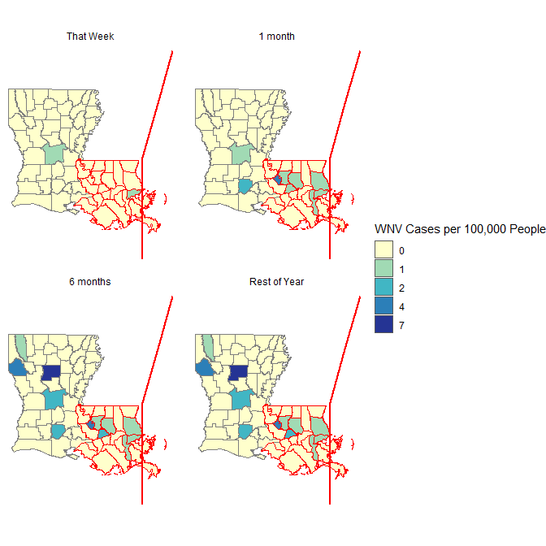

```r
#Louisiana Population
county_pops <- get_estimates(geography = "county", state = "LA", product = "population") %>%
  filter(variable == "POP")

#Louisiana map
louisiana <- counties(state="LA", class = "sf", cb = T) %>%
  mutate(fips = paste0(STATEFP,COUNTYFP)) %>%
  left_join(katrinayear, by = c("fips" = "fips")) %>%
  mutate(across(interval, factor, levels=c("That Week","1 month","6 months", "Rest of Year"))) %>%
  left_join(county_pops, by = c("fips" = "GEOID")) %>%
  mutate(incidence = cases/value *100000)


#Plot
ggplot()+
          geom_sf(data = louisiana, aes(fill = factor(round(incidence)), color = exposure))+
          geom_path(data = storm2, aes(x = longitude, y = latitude), color = "Red", size = 1)+
          scale_fill_brewer(palette = "YlGnBu")+
          scale_color_manual(values = c(NA, "red"))+
          theme_void()+
          facet_wrap(~interval)+
          guides(color = FALSE)+
          labs(fill = "WNV Cases per 100,000 People")
```

General case analysis is also accessible via `wnvstormdata` for WNV cases in Louisiana. The PDF fixed-width layout the WNV confirmed case data is published in is easy to read, making it good for communication to the public. However, it is difficult for those interested in further analysis to use. Users can use the case data provided in the `wnv_2002_2021_stormexposure` for case-specific research without using the storm exposure aspects. This could also be used to measure exposure to other climate factors, such as temperature or precipitation.

Data retrieved from the Louisiana Department of Public Health are available in this package in dataframe format. This allows for easy analysis of trends over the years:

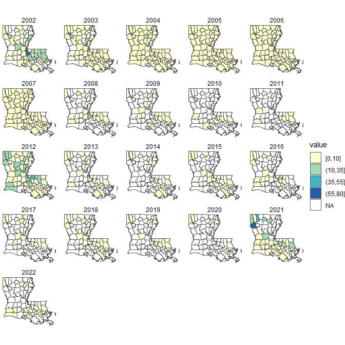

```r
plotdata <- wnv_2002_2021_stormexposure %>%
  mutate(year = year(startDate)) %>%
  group_by(year, parish) %>%
  summarize(cases = sum(cases),
            fips = unique(fips))

year <-list(year = as.numeric(unique(plotdata$year)))

#Louisiana Population
county_pops <- get_estimates(geography = "county", state = "LA", product = "population") %>%
  filter(variable == "POP")

louisiana_annual <- counties(state = "LA", class = "sf", cb = T) %>%
  mutate(year = year,
         fips = paste0(STATEFP,COUNTYFP)) %>%
  unnest(year) %>%
  left_join(plotdata, by = c("GEOID" = "fips", "year" = "year")) %>%
  left_join(county_pops, by = c("fips" = "GEOID")) %>%
  mutate(incidence = cases/value *100000)

      breaks <- c(0, 10, 35, 55, 80)
      exposure_palette <- c("#FEE5D9", "#FC9272", "#FB6A4A",
                            "#DE2D26", "#A50F15")


  louisiana_annual <- louisiana_annual %>%
      mutate(value = cut(.data$incidence, breaks = breaks,
                                   include.lowest = TRUE))

ggplot()+
  geom_sf(data =louisiana_annual, aes(fill = value))+
          scale_fill_brewer(palette = "YlGnBu")+
          theme_void()+
          facet_wrap(~year)
```

## Limitations

Some limitations are present within the West Nile Virus case data provided in this package. As noted by the Louisiana Department of Health, the WNV cases reported do not encompass all infected persons in the state. Only neuro-invasive diseases are reliably reported. Approximately one percent of asymptomatic and WNV fever cases are diagnosed and reported to the health department. Asymptomatic cases are primarily diagnosed through blood donor screenings, and WNV fever cases are tested via serologic testing. For every diagnosed case of West Nile Virus neuro-invasive disease, the health department estimates there are 90 asymptomatic infections and 10 fever-causing infections that are not reported (“West Nile Virus: LA Dept. Of Health” 2022). Despite this discrepancy, the reported data still reflects changes in the burden of disease on communities, as the estimated scale of unreported cases is the same across all observations.

## GitHub Link

To see more information on `wnvstormdata` you can access the GitHub page [here](https://github.com/jordan27r/wnvstormdata).

## References

2023. *NHC Data Archive*. https://www.nhc.noaa.gov/data/.

Anderson, Brooke, Andrea Schumacher, Seth Guikema, Steven Quiring, Joshua Ferreri, Elizabeth Tennant, and Jordan Robinson. 2021. *Stormwindmodel: Model Tropical Cyclone Wind Speeds*. https://github.com/geanders/stormwindmodel.

Caillouët, Amp; Robertson, K. A. 2020. “Temporal and Spatial Impacts of Hurricane Damage on West Nile Virus Transmission and Human Risk.” *Journal of the American Mosquito Control Association* 36.

“Symptoms, Diagnosis, &Amp; Treatment.” 2022. *Centers for Disease Control and Prevention*. Centers for Disease Control; Prevention. https://www.cdc.gov/westnile/symptoms/index.html.

“Tropical Cyclone Climatology.” 2021. *Tropical Cyclone Climatology*. https://www.nhc.noaa.gov/climo/?text.

US Department of Commerce, NOAA. 2016. “Beaufort Wind Scale.” *National Weather Service*. NOAA’s National Weather Service. https://www.weather.gov/mfl/beaufort.

“West Nile Virus: LA Dept. Of Health.” 2022. *West Nile Virus | La Dept. Of Health*. https://ldh.la.gov/page/539.